# Problem1

2024-06-06

We start by reading data and visualizing it. The transformation I am proposing consists in transforming the time in velocity: in this way the higher the value the better the performance.

```
##             name       country X100m long_jump shot_put high_jump X400m
## 1   Ashton Eaton United States 10.46      7.94    14.73      2.01 46.07
## 2    Kevin Mayer        France 10.81      7.60    15.76      2.04 48.28
## 3  Damian Warner        Canada 10.30      7.67    13.66      2.04 47.35
## 4   Kai Kazmirek       Germany 10.78      7.69    14.20      2.10 46.75
## 5 Larbi Bourrada       Algeria 10.75      7.52    13.78      2.10 47.98
## 6  Leonel Suárez          Cuba 11.21      7.14    14.27      2.07 48.15
##   X110m_hurdles discus_throw pole_vault javelin_throw X1500m
## 1         13.80        45.49        5.2         59.77 263.33
## 2         14.02        46.78        5.4         65.04 265.49
## 3         13.58        44.93        4.7         63.19 264.90
## 4         14.62        43.25        5.0         64.60 271.25
## 5         14.15        42.39        4.6         66.49 254.60
## 6         14.48        47.07        4.9         72.32 268.32
```

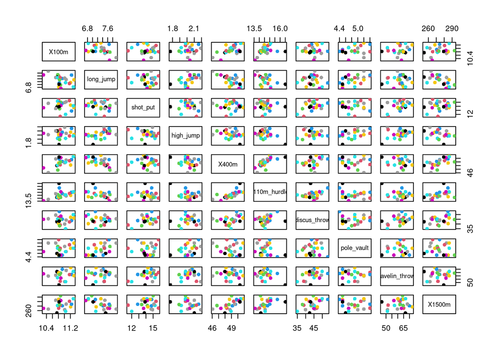

We will now plot the data and interpret the results. I propose to keep the first 3 principal components - PC1: is a weighted average of “running” and jumping variables: all velocity variables, high jump and long jump. - PC2: is a weighted average with negative weights of results in throwing events: shot put, discus throw, javelin throw. - Probably by looking at this first two PCs we are able to distinguish between sprinters and throwers. - PC3: its seems a contrast between pole vault and highjump vs X100m (postive value).

```
## Importance of components:
##                           Comp.1    Comp.2    Comp.3    Comp.4     Comp.5
## Standard deviation     1.8336038 1.3728921 1.2167275 0.9343182 0.81821028
## Proportion of Variance 0.3514926 0.1970507 0.1547718 0.0912630 0.06998984
## Cumulative Proportion  0.3514926 0.5485433 0.7033151 0.7945781 0.86456791
##                            Comp.6     Comp.7     Comp.8     Comp.9   Comp.10
## Standard deviation     0.69683500 0.61543183 0.44897518 0.40345301 0.2583582
## Proportion of Variance 0.05076508 0.03959725 0.02107414 0.01701732 0.0069783
## Cumulative Proportion  0.91533299 0.95493025 0.97600438 0.99302170 1.0000000
```

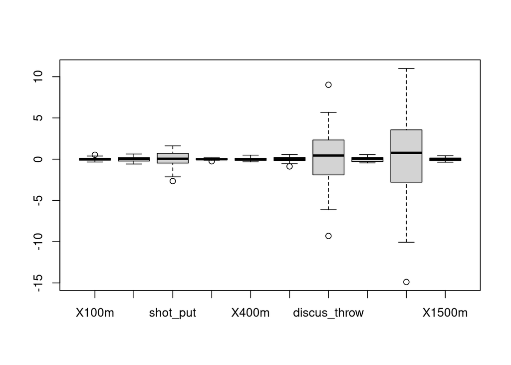

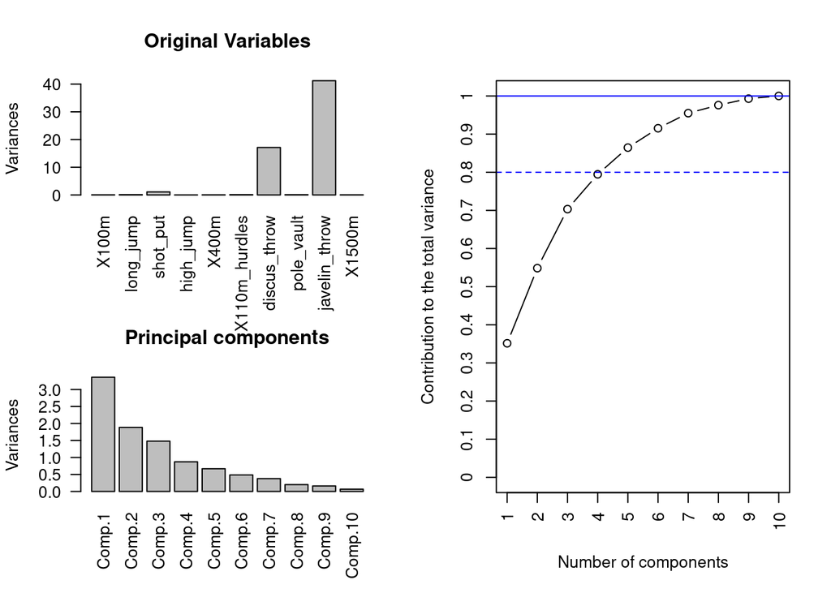

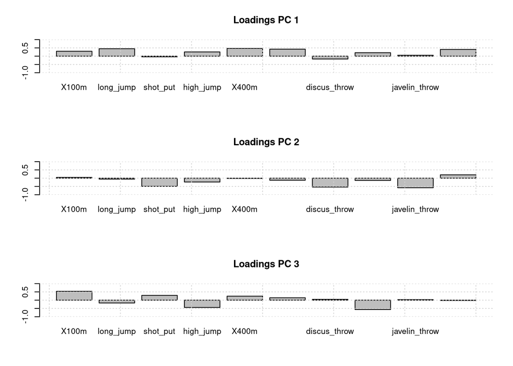

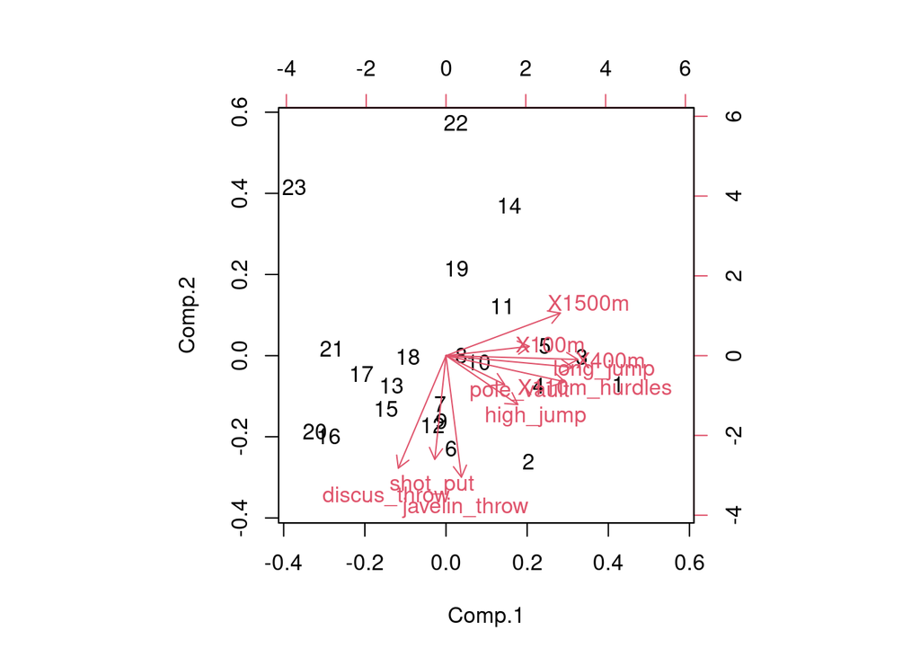

#point d) see point a) for screeplot.

#point e) It seem a pretty balanced athlete, with a good performance in all the events but the throwing ones.

```
## [1] "new athlete scores: "
```

```
##         Comp.1     Comp.2    Comp.3
## [1,] 0.5168985 0.09493683 0.3486899
```

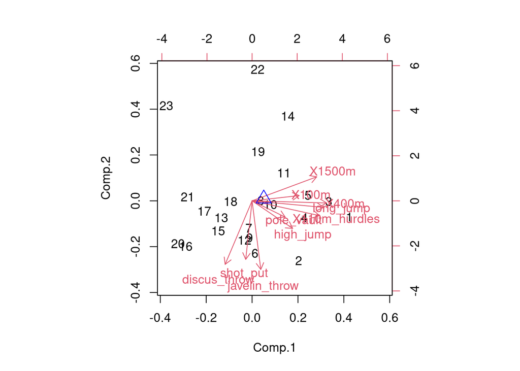